# NRES 776 Lab 10 - GLM with multiple predictors

Your name here

2023-11-16

## Bird incidence on islands

A field survey was done to record the presence or absence of Narcissus Flycatcher (*Ficedula narcissina*) across a set of islands in the western Pacific. The `area` ($km^2$) and the `isolation` (distance to the nearest island, in $km$) of the islands, and the `incidence` (presence/absence) of the bird were recorded.

In this practice, we are going to explore the relationship between presence or absence of the birds (`incidence`) vs island area (`area`) and island isolation (`isolation`).

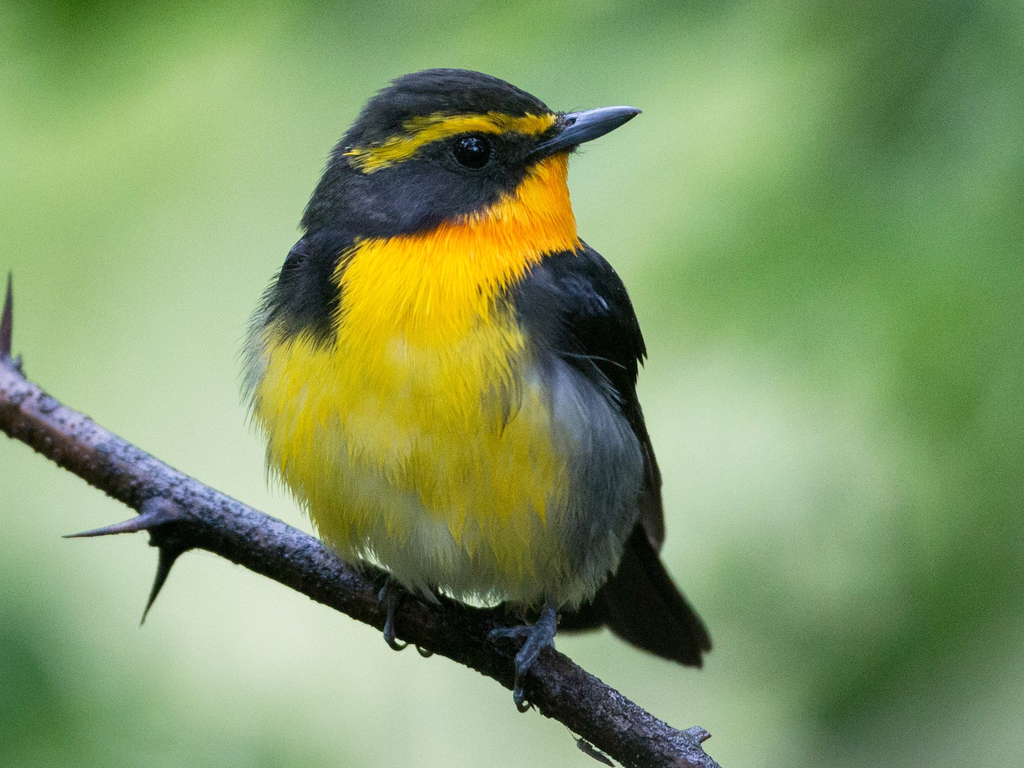

## Load required libraries and data set

```r
library(tidyverse)
library(here)
library(lmtest)

data_bird <- read_csv(here("bird.csv"))

data_bird_clean <- data_bird %>%
  mutate(incidence = as_factor(incidence))

data_bird_clean
```

```
## # A tibble: 50 × 3
##    incidence  area isolation
##    <fct>     <dbl>     <dbl>
##  1 1          7.93      3.32
##  2 0          1.92      7.55
##  3 1          2.04      5.88
##  4 0          4.78      5.93
##  5 0          1.54      5.31
##  6 1          7.37      4.93
##  7 1          8.60      2.88
##  8 0          2.42      8.77
##  9 1          6.40      6.09
## 10 1          7.20      6.98
## # ℹ 40 more rows
```

## Exploratory visualization

Seems like with the increase of the island area, there is a higher probability of detecting the species.

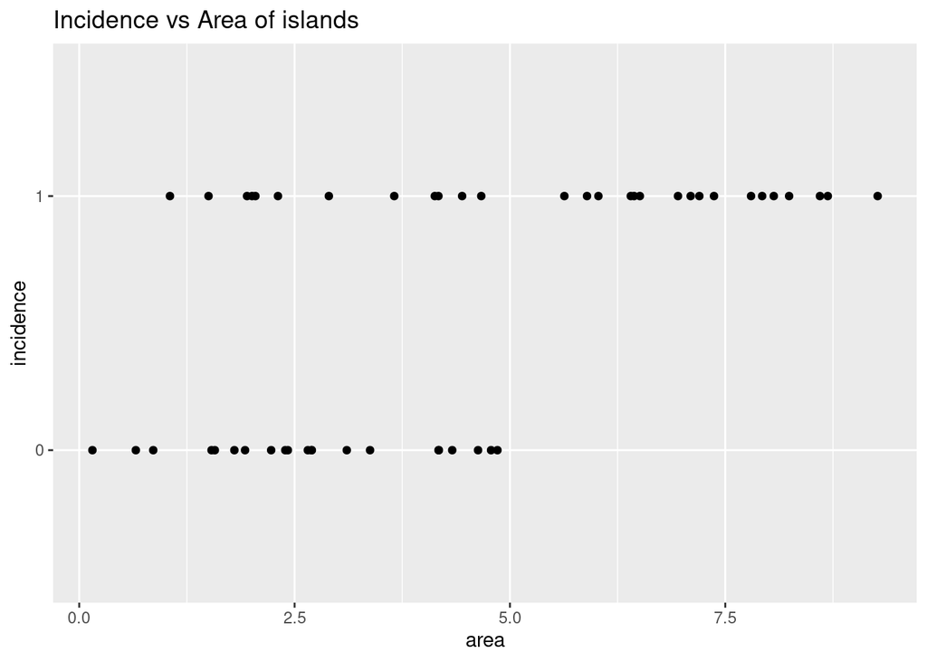

```r
ggplot(aes(x = area, y = incidence), data = data_bird_clean) +
  geom_point() +
  labs(title = "Incidence vs Area of islands")
```

Very interesting! Seems like there is a pattern showing the negative relationship between isolation and the incidence of the bird!

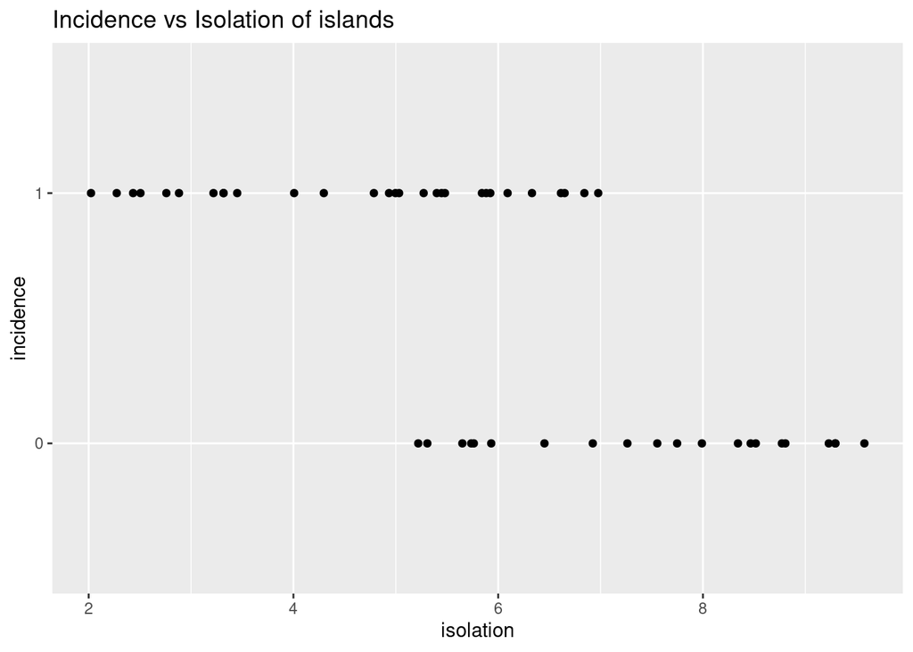

```r
ggplot(aes(x = isolation, y = incidence), data = data_bird_clean) +
  geom_point() +
  labs(title = "Incidence vs Isolation of islands")
```

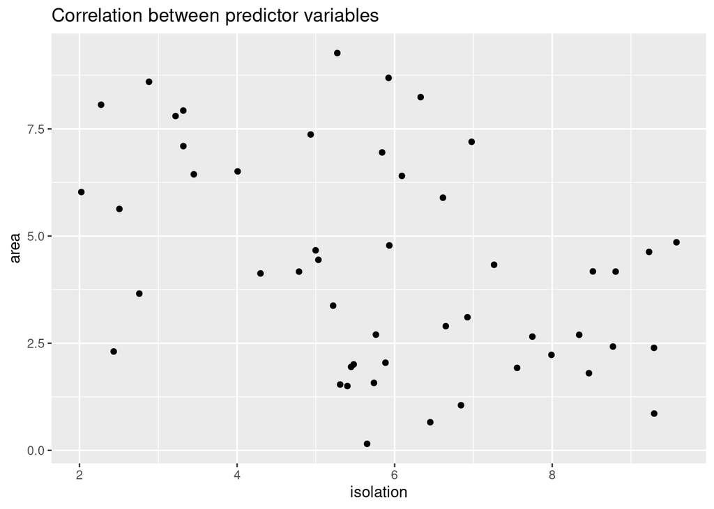

```r
ggplot(aes(x = isolation, y = area), data = data_bird_clean) +
  geom_point() +
  labs(title = "Correlation between predictor variables")
```